# Covid-19 Data Analysis

Peter Mehler

Updated April 28th 2020

# Introduction

The dataset used in this analysis is John Hopkins’ Covid-19 dataset found here: https://github.com/CSSEGISandData/COVID-19/tree/master/csse_covid_19_data/csse_covid_19_time_series. The data is presented in two documents: one for cumulative confirmed cases and the other for cumulative confirmed deaths for most countries worldwide. This information is pulled from a multitude of sources including governments and the WHO, and synthesized in this document. Values are updated daily by the owners of the database.

Both number of confirmed cases and number of confirmed deaths will be important figures in this analysis. Number of deaths is the more reliable statistic as confirmed cases relies on testing frequency and capacity. The number of confirmed cases is therefore a lower bound for the number of actual cases of COVID-19. Changes in confirmed cases could also be due to an increase in testing, so these numbers should be viewed with caution.

The importance of analyses like these cannot be understated. After watching the news daily in the last two weeks, this dataset was main source for most of the statistics presented. The number of confirmed cases, and how fast that number is growing, has been on the forefront of people’s minds worldwide. This dataset wields immense power and is extremely important to determine the severity of the situation that we find ourselves in, and is essential for strategic response.

*Text does not update with data, analysis is as of April 16th*

# Results

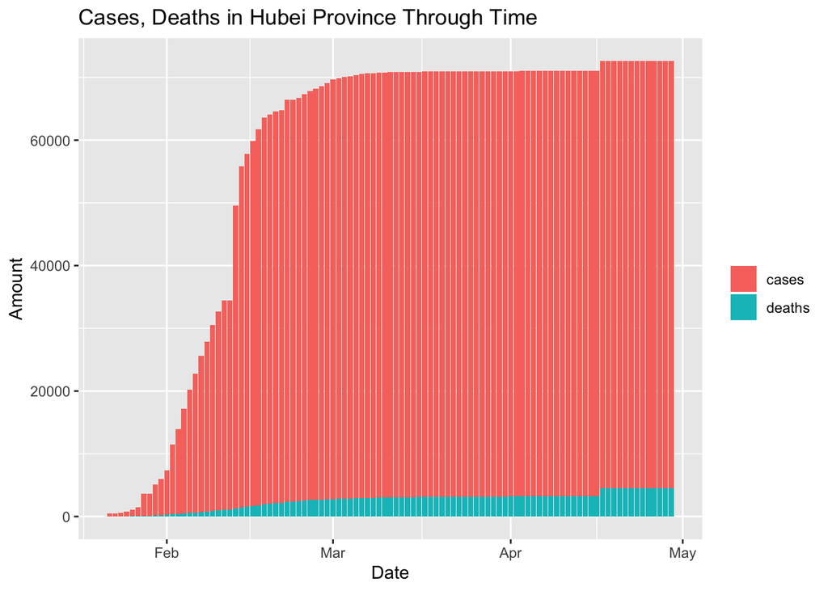

Let’s look at Italy.One look at the number of cases on the left side and it becomes clear that this graph is worse than the previous. Italy’s new daily cases are seeing a drop, we take a look at the rate of the drop in the next graph.

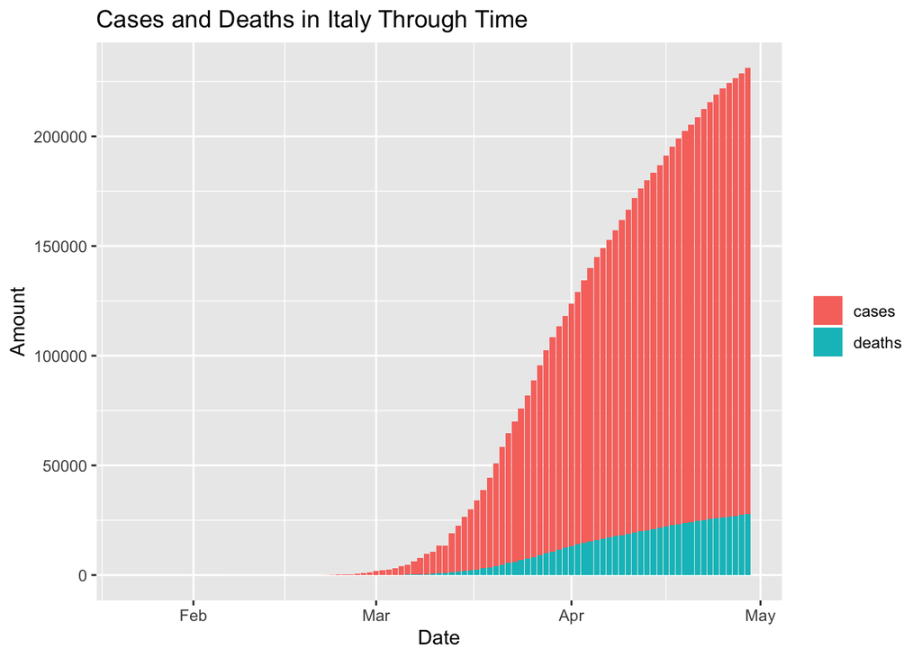

Here, a number above 0 suggests an exponential increase in deaths and new cases, and a number below 0 suggests a falling rate of infection. The rate at which the number of new reports are occuring is falling. Below 0, the disease can, in one respect, be considered under control, because the number of new cases is not building upon itself exponentially.

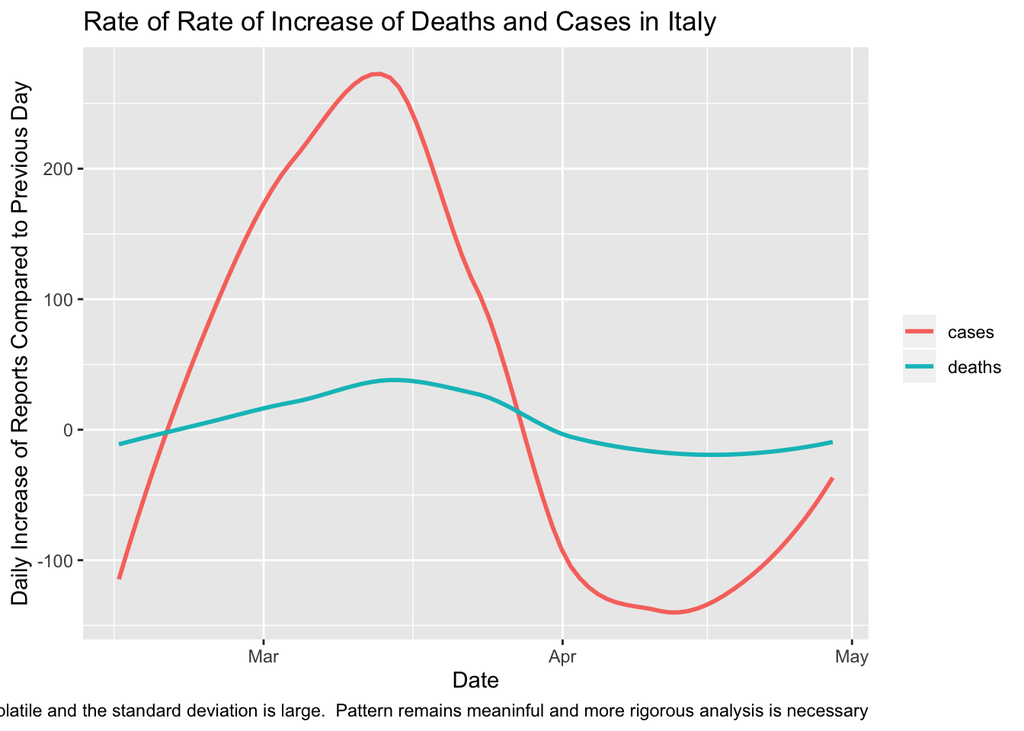

Let’s look at the same plot, but for other countries and without deaths.

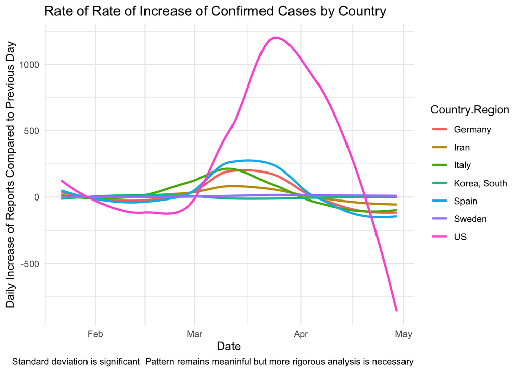

Here is the same plot, but for deaths.

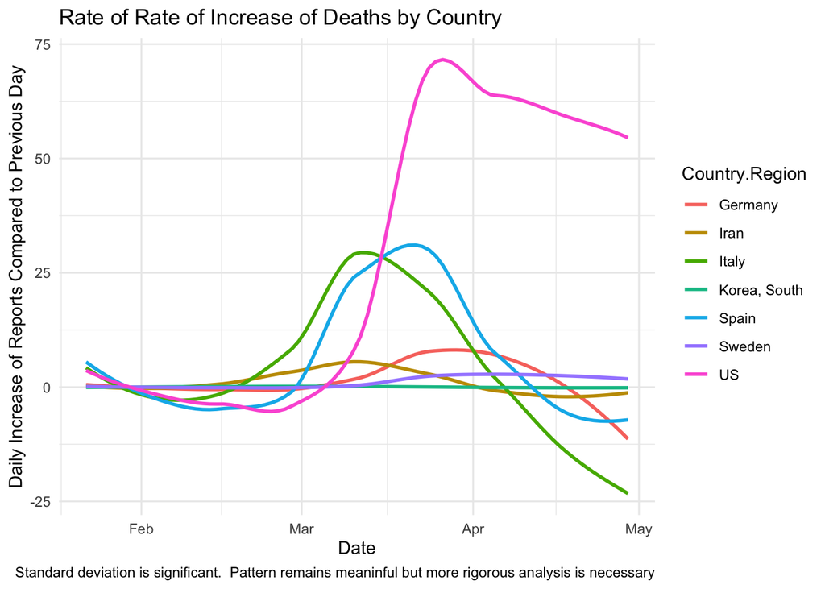

Below are the plots for cumulative deaths and cases since the beginning of the outbreak in various countries.

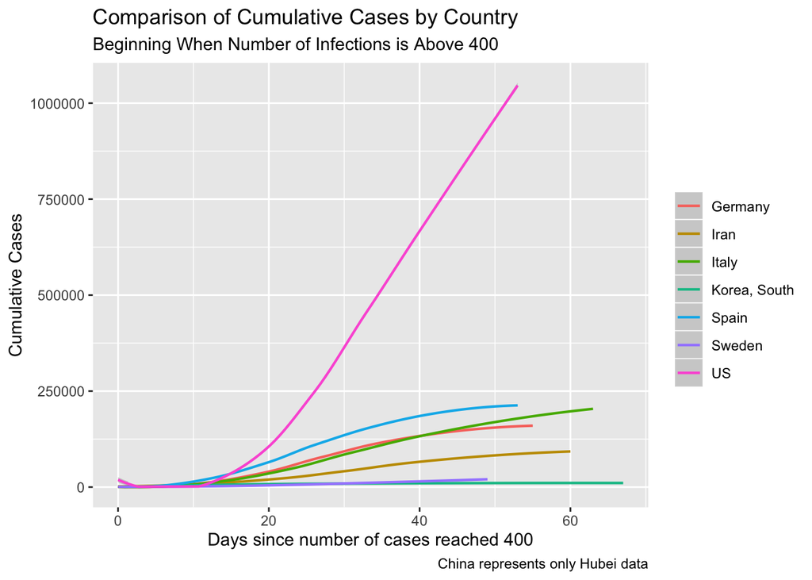

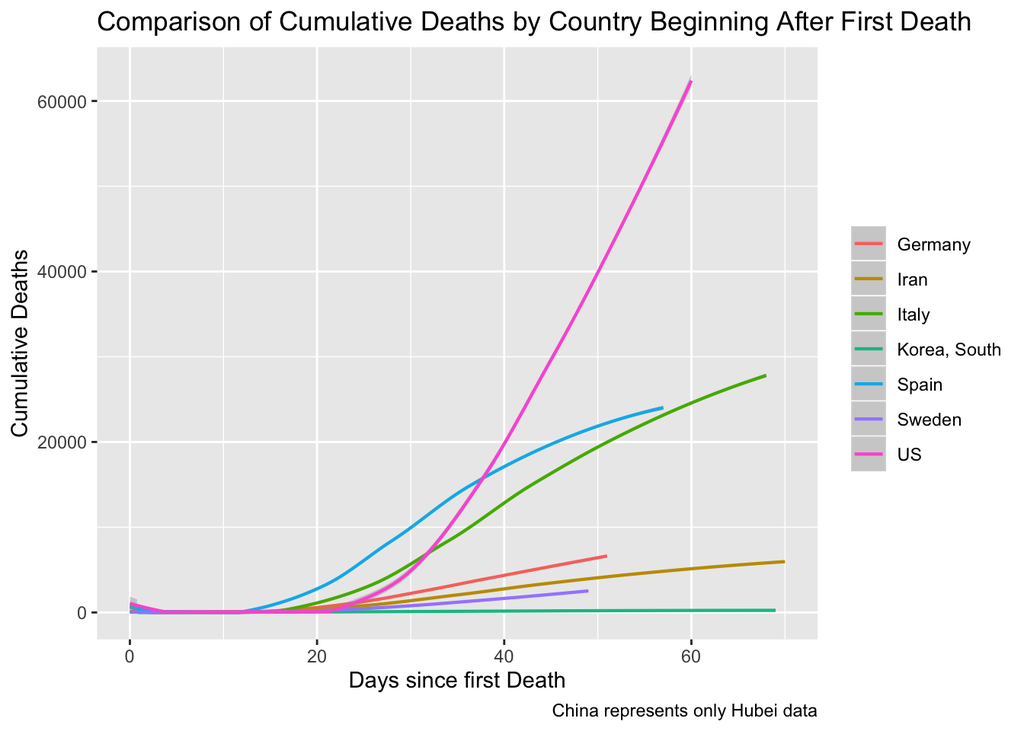

[figure not shown]

Maps below are unfinished, and I am still playing around with them!

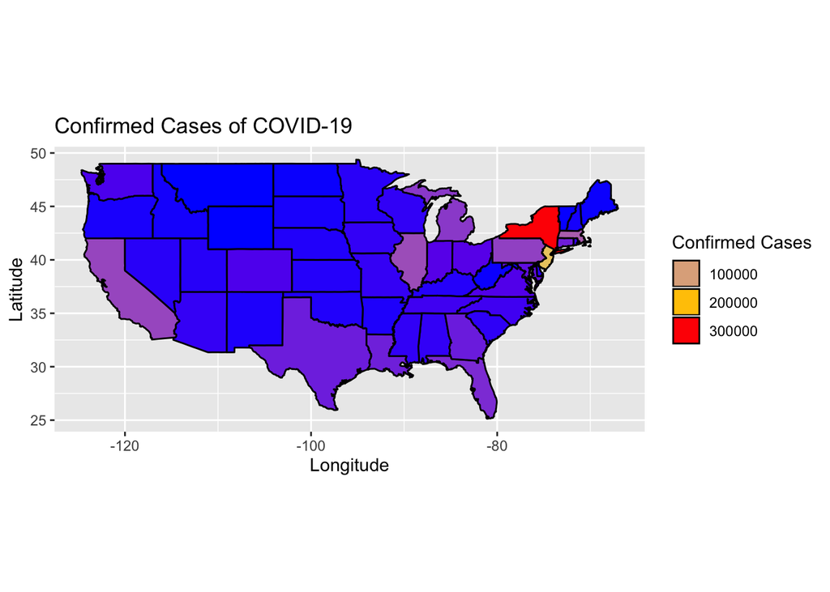

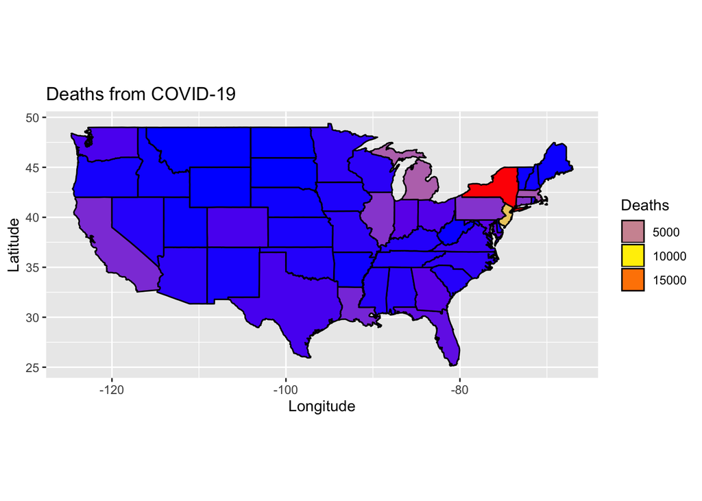

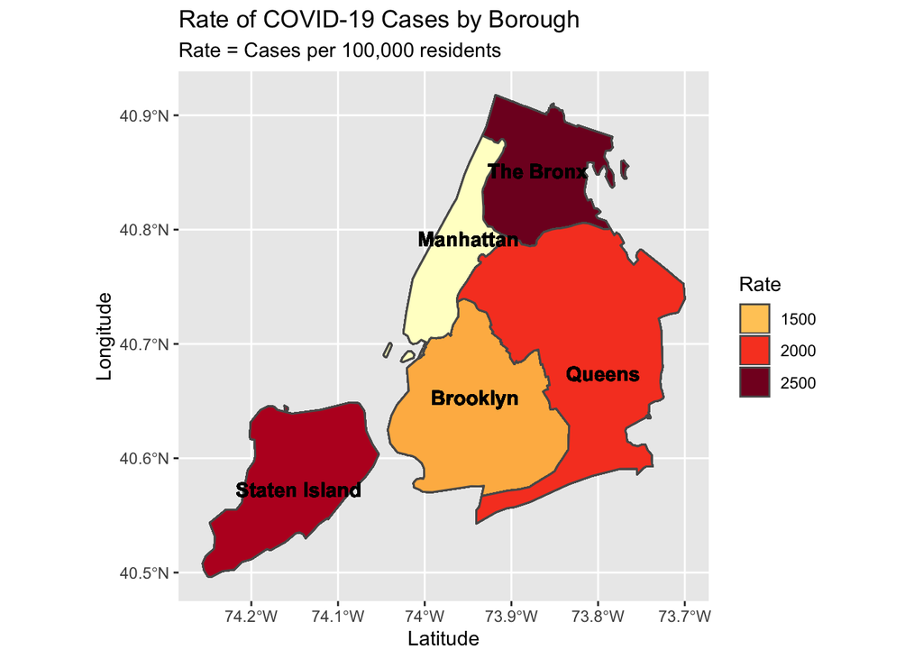

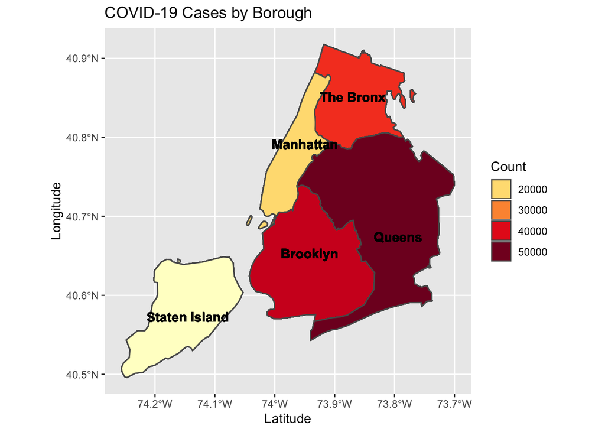

# Discussion

The conclusions of this report are changing daily with the updates of the dataset. Centralized datasets such as these are not the only information source which should inspire action, but they can play a significant role. Without data analysis during times of crisis such as this, we are relying on the individual beliefs of people. When an issue’s scope is at the level of the entire world, no amount of intuition will ever surpass the insights of large data.

This is not to say that data is infalliable. When looking into the sources of data and methods of data collection for this dataset, It becomes clear that it is far from perfect. Each country’s numbers rely on the government’s honor that reports are valid, and assumptions must be made about the confidence of data collection at multiple levels of the pipeline.

Further work is being relentlessly pursued globally. As more data come out, more questions are able to be answered. We are still unsure of the exact case fatality rate, the exact spread rate, or, perhaps most importantly, what measures best defend human life.

Aknowledgements:

https://aatishb.com/covidtrends/

https://medium.com/@tomaspueyo/coronavirus-the-hammer-and-the-dance-be9337092b56?fbclid=IwAR2xNhWfHPb1189m7moSCqS52LdWESHPF0UfXN8lf8ogZetYWUD8EONyGqY

https://medium.com/@tomaspueyo/coronavirus-act-today-or-people-will-die-f4d3d9cd99ca

https://stackoverflow.com/questions/51355303/extract-slope-of-multiple-trend-lines-from-geom-smooth

https://www.imperial.ac.uk/media/imperial-college/medicine/sph/ide/gida-fellowships/Imperial-College-COVID19-NPI-modelling-16-03-2020.pdf

https://www.youtube.com/watch?v=Kas0tIxDvrg

https://www.youtube.com/watch?v=54XLXg4fYsc&feature=share&fbclid=IwAR2MKASftMjgiAZgXzCF05iccj1nn2tA3H13LCP1EvDHyhXv1LUgPblVD-U